# Validation & tuning

This the companion notebook for the session on **validation** and **tuning** machine learning models for factor investing.

In the financial applications below, the choice of dependent variable is **not optimal**. It was chosen to minimise code complexity and ease understanding of basic principles. Results may seem disappointing, but they are **realistic**! It take experience/experimentation to make ML algorithms deliver good results. That’s up to you!

$\rightarrow$ **ABOUT THE NOTEBOOK**:

- the code chunks are **sequential**. They must be executed in the correct order.
- text between **stars** appears in bold in html format.

# 1 Variance-bias tradeoff

In this section, we illustrate how **model complexity** affect the average error and the variance of predictors. To that purpose, we use simple trees.

## 1.1 Data preparation

We start by **loading packages** and **importing the data**.

```r
library(tidyverse)  # Data wrangling (and so much more) package
library(rpart)      # Simple decision tree package
library(rpart.plot) # Tree plot package
load("data.RData")  # Load the data
data <- data  %>%   # Compute the returns
    group_by(Tick) %>%
    mutate(F_Return = lead(Close) / Close - 1,
           FL_Return = lead(Close, 12) / Close - 1) %>%     # Adding forward/future returns
    ungroup() %>%
    group_by(Date) %>%
    mutate(FR_Return = F_Return - mean(F_Return),           # Relative return vs EW market
           FLR_Return = FL_Return - mean(FL_Return)) %>%    # Relative return vs EW market (long)
    ungroup()
```

Then, we **format** the inputs we will feed the tree algorithm.

```r
normalise <-  function(v){  # This is a function that 'uniformalises' a vector
    v <- v %>% as.matrix()
    return(ecdf(v)(v))
}
data_f <- data %>%                                   # Data with normalised values
    select(-Close) %>%                               # Closing prices are not predictors
    group_by(Date) %>%                               # Normalisation takes place for each given date
    mutate_at(vars(Mkt_Cap:Prof_Marg), normalise) %>%    # Apply normalisation on numerical columns
    ungroup()
sep_date <- as.Date("2012-01-01")           # Train vs test separation date
train_sample <- data_f %>%                  # Train sample
    filter(Date <= sep_date)
test_sample <- data_f %>%                   # Test sample
    filter(Date > sep_date) %>%
    na.omit()                               # Remove missing data
```

## 1.2 Simple tree

Finally, we **train** and **test** simple trees.

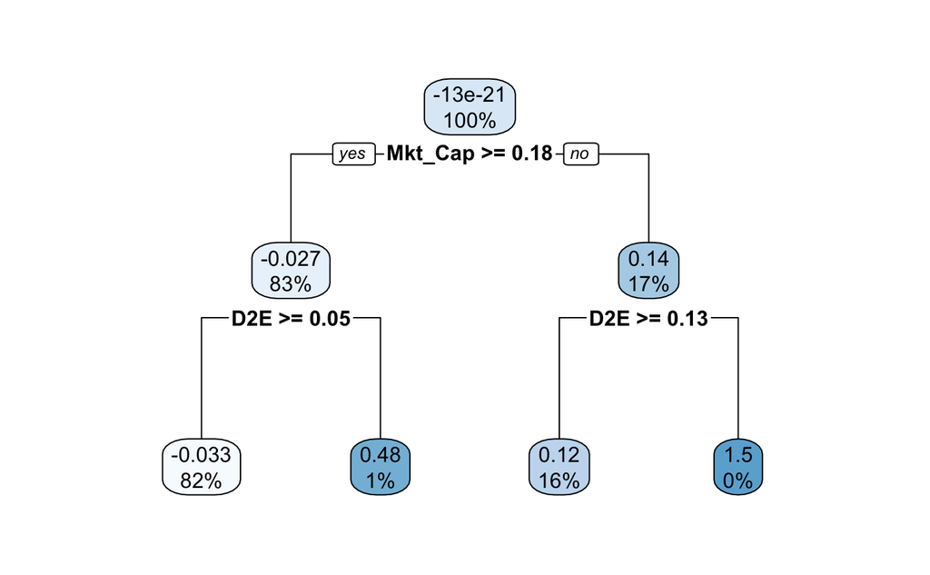

```r
fit <- rpart(FLR_Return ~ Mkt_Cap + P2B + Vol_1M + RSI_1M + D2E, # Model
             data = train_sample,                                # Data source
             cp = 0.0001,                                        # Tree complexity
             maxdepth = 2                                        # Nb levels
)                                                                # The model is then trained!
rpart.plot(fit)                                                  # Plot the tree
```

In the above code, we impose a small complexity (**cp**) so that we can **manually control** the depth (and hence, the complexity) of the tree. Given the trained parameters (splits), we test the model on the recent data.

```r
pred <- predict(fit, test_sample)           # Predictions
mean(pred)-mean(test_sample$FLR_Return)     # Bias
```

```
[1] 0.009595241
```

```r
var(pred)                                   # Variance
```

```
[1] 0.01085778
```

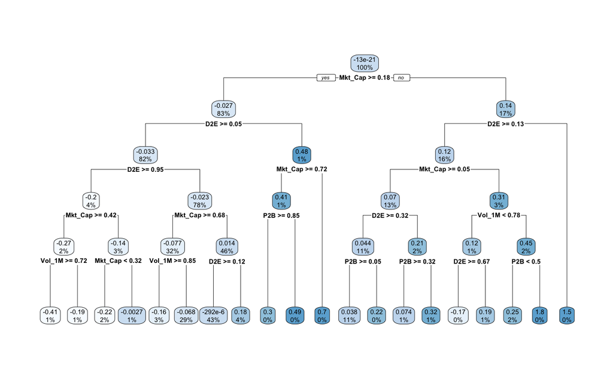

```r
fit <- rpart(FLR_Return ~ Mkt_Cap + P2B + Vol_1M + RSI_1M + D2E, # Model
             data = train_sample,                                # Data source
             cp = 0.0001,                                        # Tree complexity
             maxdepth = 5                                        # Nb levels
)                                                                # The model is then trained!
rpart.plot(fit)                                                  # Plot the tree
```

Graphically, the model is evidently more complex. And the predictions follow.

```r
pred <- predict(fit, test_sample)
mean(pred)-mean(test_sample$FLR_Return) # Bias
```

```
[1] -0.005559628
```

```r
var(pred)                               # Variance
```

```
[1] 0.02271377
```

The changes in both values follow opposite paths. The **magnitude of bias** is divided by almot two (from 1% to 0.6%) while the variance more than doubles (from 1.1% to 2.3%). This is clear evidence of the **variance-bias tradeoff**.

# 2 Grid search

In this section, we have a look on the **impact of hyperparameters on model performance**. Because of computational constraints, we work with **boosted trees** (neural networks take too much time!).

## 2.1 Naive approach

We start by preparing the inputs. Because we work with the simple (scaled) features, the dependent variable is the 12M (smooth) return. Additionally, we will in fact use the return **relative** to the average performance (FLR_Return variable).

```r
library(xgboost)                                                         # Load package
features <- c("Mkt_Cap", "P2B", "Vol_1M", "RSI_1M", "D2E", "Prof_Marg")  # Predictors
train_features <- train_sample %>% select(features) %>% as.matrix()      # Independent variables
train_label <- train_sample$FLR_Return                                   # Dependent variable
train_matrix <- xgb.DMatrix(data = train_features, label = train_label)  # XGB format
test_features <- test_sample %>% select(features) %>% as.matrix()        # Independent variables
test_label <- test_sample$FLR_Return                                     # Dependent variable
```

**Note**: some other parameters are also important (and related), like **maximum depth**, or the **number of rounds** (i.e., trees), but we stick to 3 of them for simplicity purposes.

We start by defining (**agnostically at first**) the sets of parameter values.

```r
eta <- c(0.5, 0.6, 0.7, 0.8, 0.9)       # eta values
gamma <- c(0.02, 0.2, 1, 3, 10)         # gamma values
lambda <- c(0.01, 0.1, 1, 10, 100)      # lambda values
pars <- expand.grid(eta, gamma, lambda) # Exploring all combinations!
eta <- pars[,1]
gamma <- pars[,2]
lambda <- pars[,3]
```

Below, we code the function that we will use for the grid search. It takes train and test data as inputs, as well as the parameters we are interested in.

```r
grid_par <- function(train_matrix, test_features, test_label, eta, gamma, lambda){
    fit <- train_matrix %>%
        xgb.train(data = .,                       # Data source (pipe input)
                  eta = eta,                      # Learning rate
                  objective = "reg:linear",       # Objective function
                  max_depth = 5,                  # Maximum depth of trees
                  lambda = lambda,                # Penalisation of leaf values
                  gamma = gamma,                  # Penalisation of number of leaves
                  nrounds = 10,                   # Number of trees used
                  verbose = 0                     # No comment
        )

    pred <- predict(fit, test_features)           # Preditions based on fitted model & test values
    return(mean((pred-test_label)^2))             # Mean squared error
}
```

Finally, we test the function on one triplet of parameter values and then on all combinations, using the **pmap**() function. From the output, we create a graph.

```r
grid_par(train_matrix, test_features, test_label, 0.1, 0.1, 0.1) # Test of the function
```

```
[1] 0.07907365
```

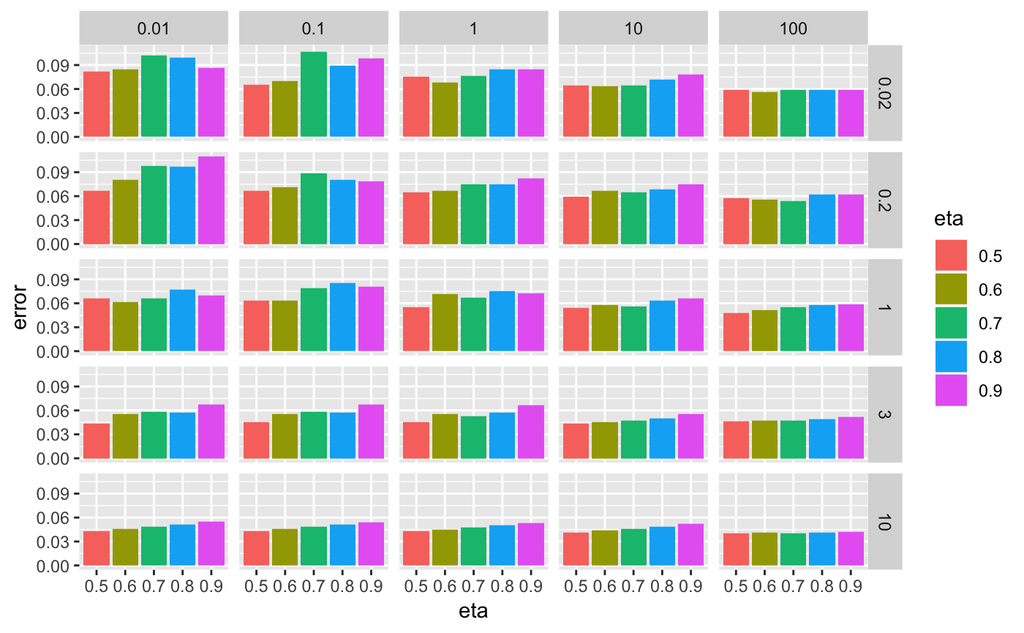

```r
grd <- pmap(list(eta, gamma, lambda),                 # Parameters for the grid search
            grid_par,                                 # Function on which to apply the grid search
            train_matrix = train_matrix,              # Input for function: training data
            test_features = test_features,            # Input for function: test features
            test_label = test_label                   # Input for function: test labels (returns)
)
grd <- data.frame(eta, gamma, lambda, error = unlist(grd)) # Dataframe with all results
grd$eta <- as.factor(eta)                                  # Parameters as categories (for plotting)
grd %>% ggplot(aes(x = eta, y = error, fill = eta)) +      # Plot!
    geom_bar(stat = "identity") +
    facet_grid(rows = vars(gamma), cols = vars(lambda))
```

```r
var(test_label)                                            # Benchmark = zero prediction
```

```
[1] 0.03645044
```

The final value is a good benchmark. It’s the quadratic error we would make if we predicted a zero return at all times.

There is one emerging pattern: **gamma** (from top to bottom barplots) and **lamda** (from left to right) seem to be the main drivers of the error at this scale. The problem is that high values of both parameters correspond to almost constant models and they are those with the smallest error.

The simplest (constant) prediction is the best (high values of **gamma** and **lambda**). This is an illustration of **frugal forecasting**: when sophisticated models are outperformed by naive or heuristic benchmarks.

Overall, the performance of the models is not impressive. One possible reason for that is that the dataset is not wide enough: with only 30 assets, it is hard to learn patterns. A second explanation would be that the chosen model is not a good option. A third option is that we are not looking at the right metric and that we are maybe facing a false negative. Finally, a fourth option is that the **label** we work with is not consistent with the chosen **features**.

## 2.2 Separating loss from performance

This is where we choose to shift from the **ML metric** to the **financial metric**. Since we are rebanlancing monthly, we will need an indicator that is best suited. Below, we record the **hit ratio** for the one-month ahead return, i.e., the percentage of times that the prediction is in the right direction.

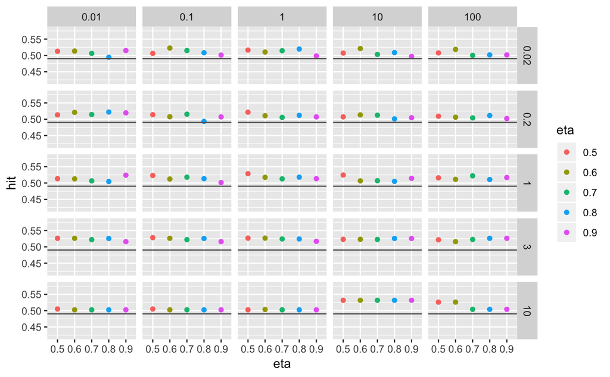

```r
grid_par_hit <- function(train_matrix, test_features, test_label, eta, gamma, lambda){
    fit <- train_matrix %>%
        xgb.train(data = .,                       # Data source (pipe input)
                  eta = eta,                      # Learning rate
                  objective = "reg:linear",       # Objective function
                  max_depth = 5,                  # Maximum depth of trees
                  lambda = lambda,                # Penalisation of leaf values
                  gamma = gamma,                  # Penalisation of number of leaves
                  nrounds = 10,                   # Number of trees used
                  verbose = 0                     # No comment
        )

    pred <- predict(fit, test_features)           # Preditions based on fitted model & test values
    return(mean(pred*test_label>0))               # Hit ratio!
}
test_label_hit <- test_sample$FR_Return              # Dependent variable => very different!!!
grd <- pmap(list(eta, gamma, lambda),                # Parameters for the grid search
            grid_par_hit,                            # Function of the grid search
            train_matrix = train_matrix,             # Input for function: training data
            test_features = test_features,           # Input for function: test features
            test_label = test_label_hit              # Input for function: test labels (returns)
)
grd <- data.frame(eta, gamma, lambda, hit = unlist(grd)) # Dataframe with all results
grd$eta <- as.factor(eta)                                # Parameters as categories (for plotting)
grd %>% ggplot(aes(x = eta, y = hit, color = eta)) +     # Plot!
    geom_point() +
    ylim(0.42,0.58) +
    geom_hline(yintercept = mean(test_label_hit>0), color = "#646464") + # Benchmark value
    facet_grid(rows = vars(gamma), cols = vars(lambda))
```

```r
mean(test_label_hit>0)     # Benchmark: assuming constant positive return (e.g., EW portfolio!)
```

```
[1] 0.4902564
```

```r
max(grd$hit)               # Best hit ratio from models
```

```
[1] 0.5317949
```

The validation metric is the **hit ratio** over the FR_Return. The latter is the 1M forward return over the cross-sectional average return. This means that the hit ratio measures the proportion of times we bet on a stock that will outperform the average return of all stocks in the dataset.

All hit ratios are above those of the benchmark, which is a good sign. Many of them are above 0.50, which is even better. In practice, a hit ratio below 0.52 is probably not worth much (due to **transaction costs**).

Below, we test the performance metrics that is most obvious to portfolio managers: the **average return**. The only change is in the **return**() argument in the function **grid_par_ret**(). We invest in the stock if its prediction is strictly positive.

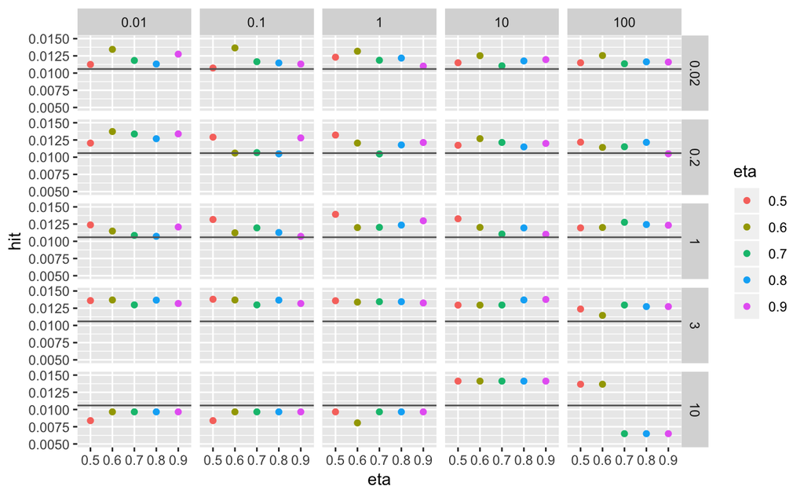

```r
grid_par_ret <- function(train_matrix, test_features, test_label, eta, gamma, lambda){
    fit <- train_matrix %>%
        xgb.train(data = .,                       # Data source (pipe input)
                  eta = eta,                      # Learning rate
                  objective = "reg:linear",       # Objective function
                  max_depth = 5,                  # Maximum depth of trees
                  lambda = lambda,                # Penalisation of leaf values
                  gamma = gamma,                  # Penalisation of number of leaves
                  nrounds = 10,                   # Number of trees used
                  verbose = 0                     # No comment
        )

    pred <- predict(fit, test_features)           # Preditions based on fitted model & test values
    return(mean(test_label[pred>0]))              # Mean return when prediction > 0 !
}
test_label_ret <- test_sample$F_Return            # Dependent variable => very different!!!
grd <- pmap(list(eta, gamma, lambda),                # Parameters for the grid search
            grid_par_ret,                            # Function of the grid search
            train_matrix = train_matrix,             # Input for function: training data
            test_features = test_features,           # Input for function: test features
            test_label = test_label_ret              # Input for function: test labels (returns)
)
grd <- data.frame(eta, gamma, lambda, hit = unlist(grd)) # Dataframe with all results
grd$eta <- as.factor(eta)                                # Parameters as categories (for plotting)
grd %>% ggplot(aes(x = eta, y = hit, color = eta)) +     # Plot!
    geom_point() +
    ylim(0.005,0.015) +
    geom_hline(yintercept = mean(test_label_ret), color = "#646464") + # Benchmark value
    facet_grid(rows = vars(gamma), cols = vars(lambda))
```

```r
mean(test_label_ret)                                                   # Benchmrk: average EW return
```

```
[1] 0.0105876
```

In raw value, there seems to be a robust zone of outperformance for gamma = 3. Nevertheless, this does not take into account **transaction costs**. They should be computed to make sure that the performance does not vanish with trading fees.

# 3 Hyperparameters through time

## 3.1 Setup

In this section, we investigate the impact of time on the validity of hyperparameters. We split the sample into three parts:

| Part | Training starts | Validation starts | Validation ends |
| --- | --- | --- | --- |
| Part 1 | 2000-01-01 | 2004-01-01 | 2006-01-01 |
| Part 2 | 2005-01-01 | 2009-01-01 | 2011-01-01 |
| Part 3 | 2010-01-01 | 2014-01-01 | 2016-01-01 |

The parts have a five year lag. The training sample is 4 year long, while validation is performed over 2 years. Hence, each study requires 6 years of data. We will separate the validation stage from the testing stage.

```r
train_start = c("2000-01-01", "2005-01-01", "2010-01-01")
val_start = c("2004-01-01", "2009-01-01", "2014-01-01")
test_start = c("2006-01-01", "2011-01-01", "2016-01-01")
stop_date = c("2008-01-01", "2013-01-01", "2018-01-01")
# Below, the parameters
gamma <- c(0.02, 0.2, 1, 3, 10)         # gamma values
lambda <- c(0.01, 0.1, 1, 10, 100)      # lambda values
pars <- expand.grid(gamma, lambda)      # Exploring all combinations!
gamma <- pars[,1]
lambda <- pars[,2]
```

Working with time series adds one dimension, hence we restrict our study to only two parameters: **gamma** and **lambda**. This will ease the visual representation of the results. We fix the learning rate **eta** to a reasonable value of 0.8.

## 3.2 Validation

Because we want to compare outcomes at three different points in time, we work with the hit-ratio, the average level of which is not dependent on economic cycles (as are returns, for instance). Hence, we recycle the **grd_par_hit**() function built above. For simplicity, we resort to a simple loop over the three periods.

```r
grd <- c()       # Initiate output
for(i in 1:3){   # Loop over the parts
    # FIRST, WE PREPARE THE DATE
    train_features <- data_f %>%                                 # Data
        filter(Date >= train_start[i], Date < val_start[i]) %>%  # Date filter
        select(features) %>% as.matrix()                         # Keep features
    train_label <- data_f %>%                                    # Data
        filter(Date >= train_start[i], Date < val_start[i]) %>%  # Date filter
        select(FLR_Return) %>% as.matrix()                       # Keep dependent variable
    train_matrix <- xgb.DMatrix(data = train_features, label = train_label)  # XGB format
    val_features <- data_f %>%                                   # Data
        filter(Date >= val_start[i], Date < test_start[i]) %>%   # Date filter
        select(features) %>% as.matrix()                         # Keep features
    val_label <- data_f %>%                                      # Data
        filter(Date >= val_start[i], Date < test_start[i]) %>%   # Date filter
        select(FR_Return)                                        # Keep dependent variable
    # SECOND, WE COMBINE pmap() AND grid_par_hit() & AGGREGATE ITERATIVELY
    grd_temp <- pmap(list(0.8, gamma, lambda),           # Parameters for the grid search
                grid_par_hit,                            # Function of the grid search
                train_matrix = train_matrix,             # Input for function: training data
                test_features = val_features,            # Input for function: test features
                test_label = val_label                   # Input for function: test labels (returns)
    )
    grd <- rbind(grd,                                                  # Output of previous part(s)
        data.frame(part = i, gamma, lambda, hit = unlist(grd_temp)))   # Output of latest part
}
```

Finally, we format and plot.

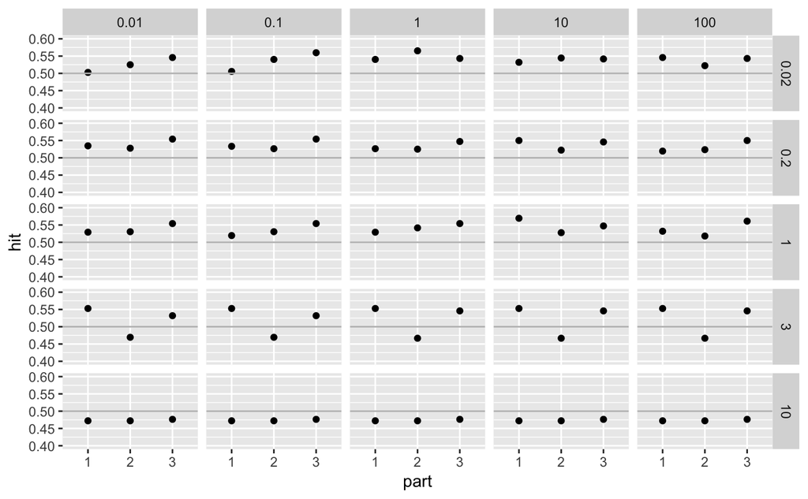

```r
grd %>%
    mutate_at(vars(part:lambda), as.factor) %>%  # Change numbers into factors for plotting
    ggplot(aes(x = part, y = hit)) +
    geom_point() +
    ylim(0.4,0.6) +
    geom_hline(yintercept = 0.5, color = "grey") +
    facet_grid(gamma ~ lambda)
```

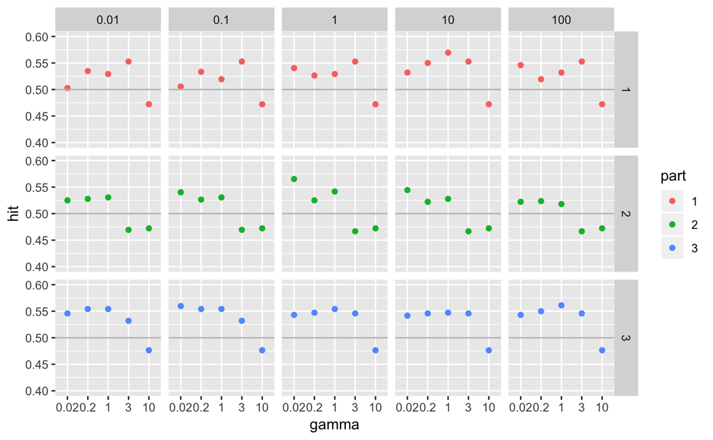

```r
grd %>%
    mutate_at(vars(part:lambda), as.factor) %>%  # Change numbers into factors for plotting
    ggplot(aes(x = gamma, y = hit, color = part)) +
    geom_point() +
    ylim(0.4,0.6) +
    geom_hline(yintercept = 0.5, color = "grey") +
    facet_grid(part ~ lambda)
```

We provide two alternative representation of the results. In the first one, the x-axis is linked to the **chronology** to assess stability of results over time. In the second one, parts are grouped in color so that we can assess which choices would have been made in a ‘**live**’ situation.

From the first graph, we see that apart for gamma = 3, the values are relatively stable. It also shows that gamma = 10 is not the best choice we can make (too much penalisation leads to a constant/simplistic prediction).

## 3.3 Test

For simplicity, we will work with constant parameters in what follows. A full rigorous treatment would impose that the validation be carried out at each period (month) of the backtest in order to choose **optimal hyperparameters**. We posit that there is some stability in the performance of hyperparameter values and start by looking at the average values over the 3 periods.

In order to choose the parameters, we compute averages.

```r
grd %>% group_by(gamma, lambda) %>%
    summarise(avg_hit = mean(hit)) %>%
    spread(key = lambda, value = avg_hit)
```

| gamma | 0.01 | 0.1 | 1 | 10 | 100 |
| --- | --- | --- | --- | --- | --- |
| 0.02 | 0.5245370 | 0.5351852 | 0.5495370 | 0.5393519 | 0.5370370 |
| 0.20 | 0.5388889 | 0.5379630 | 0.5328704 | 0.5393519 | 0.5310185 |
| 1.00 | 0.5379630 | 0.5347222 | 0.5416667 | 0.5481481 | 0.5370370 |
| 3.00 | 0.5180556 | 0.5180556 | 0.5217593 | 0.5217593 | 0.5217593 |
| 10.00 | 0.4736111 | 0.4736111 | 0.4736111 | 0.4736111 | 0.4736111 |

Two stable values for **gamma** are 0.2 and 1, while 1 and 10 are good points for **lambda**, as long as gamma is not too high. For simplicity, we thus choose *gamma = lambda = 1*. In **xgboost**, the default value for lambda is indeed 1, but it is 0 for gamma.

To avoid look-ahead bias, we will only work with data posterior to the last validation point (December 2015). But since we have been working with 12M forward dependent variable, we must shift the starting data to January 2017. This removes any possible **overlap**!

We then recycle code from the session on **Decision Trees** below and start with data preparation and initialisation.

```r
tick <- levels(data$Tick)                     # Set of assets
sep_date <- as.Date("2017-01-01")             # This date separates in-sample vs out-of-sample
t_oos <- data$Date[data$Date > sep_date] %>%  # Out-of-sample dates (i.e., testing set)
    unique() %>%
    as.Date(origin = "1970-01-01")
Tt <- length(t_oos) - 1                                         # Nb of dates, avoid T = TRUE
nb_port <- 2                                                    # Nb of portfolios
portf_weights <- array(0, dim = c(Tt, nb_port, length(tick)))   # Store weights
portf_returns <- matrix(0, nrow = Tt, ncol = nb_port)           # Store returns
```

Below, we adjust the weight function, with the **equally-weighted** (EW) portfolio as **benchmark**. We will invest in the 15 stocks with the highest (predicted) relative 12M outperformance.

```r
weights_multi <- function(train_data, test_data, j){
    N <- test_data$Tick %>% levels() %>% length() # Number of stocks
    features <- c("Mkt_Cap", "P2B", "Vol_1M", "RSI_1M", "D2E", "Prof_Marg") # Hard-coded
    if(j == 1){                             # j = 1 => EW
        return(rep(1/N,N))
    }
    if(j == 2){                             # j = 2 => tree-based
        # Below, we quickly format the data
        train_features <- train_data %>% select(features) %>% as.matrix()       # Indep. variable
        train_label <- train_data$FLR_Return                                    # Dependent variable
        train_matrix <- xgb.DMatrix(data = train_features, label = train_label) # XGB format
        fit <- train_matrix %>%
            xgb.train(data = .,                       # Data source (pipe input)
                      eta = 0.8,                      # Learning rate
                      objective = "reg:linear",       # Number of random trees
                      max_depth = 5,                  # Maximum depth of trees
                      nrounds = 10,                   # Number of trees used
                      lambda = 1,                     # Fixed value of hyperparameter
                      gamma = 1                       # Fixed value of hyperparameter
            )
        xgb_test <- test_data %>%                     # Test sample => XGB format
            select(features) %>%
            as.matrix() %>%
            xgb.DMatrix

        pred <- predict(fit, xgb_test)                # Single prediction
        return((pred>median(pred))/15)                # Fifteen largest values, equally-weighted
    }
}
```

And we proceed to the backtesting loop.

```r
train_window <- 365 * 6                                 # We train on rolling windows of 6-1=5 years
for(t in 1:Tt){                                         # Loop on dates!
    train_data <- data_f %>%
        filter(Date < t_oos[t] - 365,                   # One year offset because FLR_Return
               Date >= t_oos[t]- train_window)          # Rolling window !!!
    test_data <- data_f %>% filter(Date == t_oos[t])    # Current values
    for(j in 1:nb_port){
        portf_weights[t,j,] <- weights_multi(train_data, test_data, j)  # Hard-coded params, beware!
        realized_returns <- data %>%                    # Computing returns via:
            filter(Date ==  t_oos[t]) %>%               # Filtering
            select(F_Return)                            # Selecting
        portf_returns[t,j] <- sum(portf_weights[t,j,] * realized_returns)
    }
}
apply(portf_returns, 2, mean) / apply(portf_returns, 2, sd) # Sharpe ratios!
```

```
[1] 0.1974907 0.2886063
```

The ML-driven strategy is well above the EW portfolio in terms of **raw Sharpe ratio**.

Finally, below, we plot the evolution of the two portfolios.

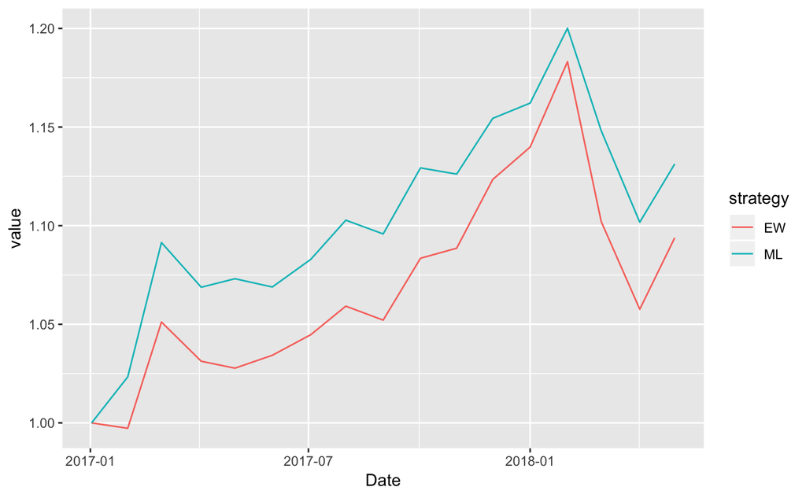

```r
plot_data <- (portf_returns+1) %>% apply(2,cumprod) # Values
plot_data <- rbind(1, plot_data)                    # Initiate at one
plot_data <- data.frame(t_oos, plot_data)           # Adding the date
colnames(plot_data) <- c("Date", "EW", "ML")        # Changing column names
plot_data %>%                                       # Final formatting & plot
    gather(key = strategy, value = value, -Date) %>%
    ggplot(aes(x = Date, y = value, color = strategy)) +
    geom_line()
```

# 4 Exercises

## 4.1 Random Forests

Explore the sensitivity of performance of random forest using grid search for the two key parameters: **ntree** (number of trees in the forest) and **mtry** (number of variables). We recommend to:

1. work on the large dataset (10 features)
2. keep **mtry** between 4 and 8 and **ntree** between 10 and 200.

Don’t forget to change/update the **feature space**!